# My visual data story

## Introduction

I am analysing the texts I receive and way I respond/react to texts.

I wanted to explore what the texts I receive are about, who sends me the most texts, how the number of texts vary by sender, and more.

I only filled out my survey when someone initiated a text conversation with me, and I did not fill in the survey for replies within a conversation. So each survey entry represents the initiation text for a new conversation.

The questions in my survey were:

- Background question: Were your text notifications on or off when you were sent the text?
- How long after the text was sent did you see it? Enter a number in minutes (E.g. 0.5 for 30 seconds, 5 for 5 minutes, 90 for 1.5 hours). Use a zero before decimals.
- Who is the text from? (MCA: Friend, Family, Acquaintance, Co worker, Unknown number, Automated service)
- How many texts did they send at once?
- What is the main topic of the text?
- How did you respond to the message? (MCA: Reply immediately, Take action (E.g. check something, book an appointment), Read it and decide to respond later, Doesn’t require a response).

## Time of day X Response

This first graph looks at how the time of day (morning (before 12pm), afternoon (12pm-5pm), or evening (after 5pm) ) I see a text affects the way I respond.

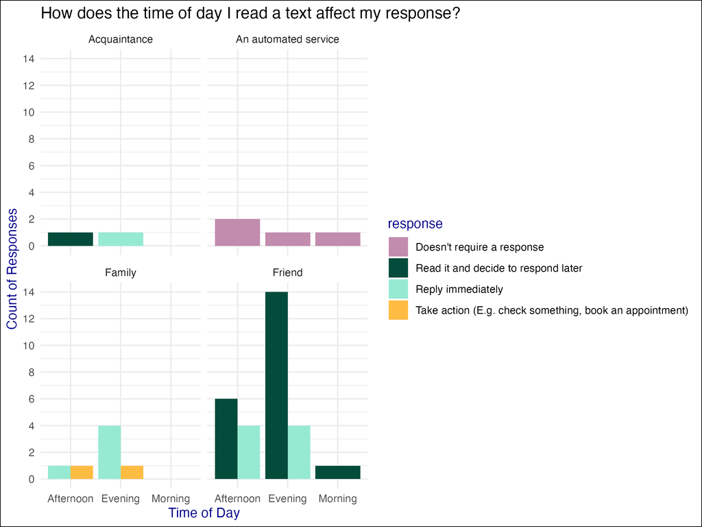

## Notifications X Delay

This second graph looks at how having my notifications on or off affects how long it takes me to see a text. This graph is produced using only the 20 new observations I collected for Project 4 since the question about how long it took me to see a text was only added after Project 2.

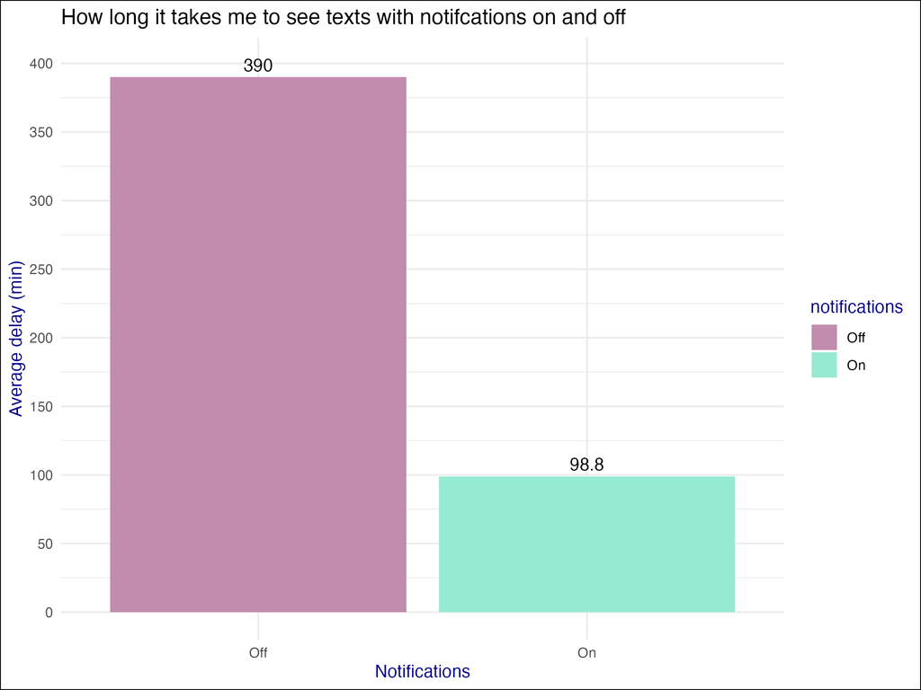

## Sender X Number of texts

This graph looks at how the number of texts someone sends at once to me varies by who is sending it.

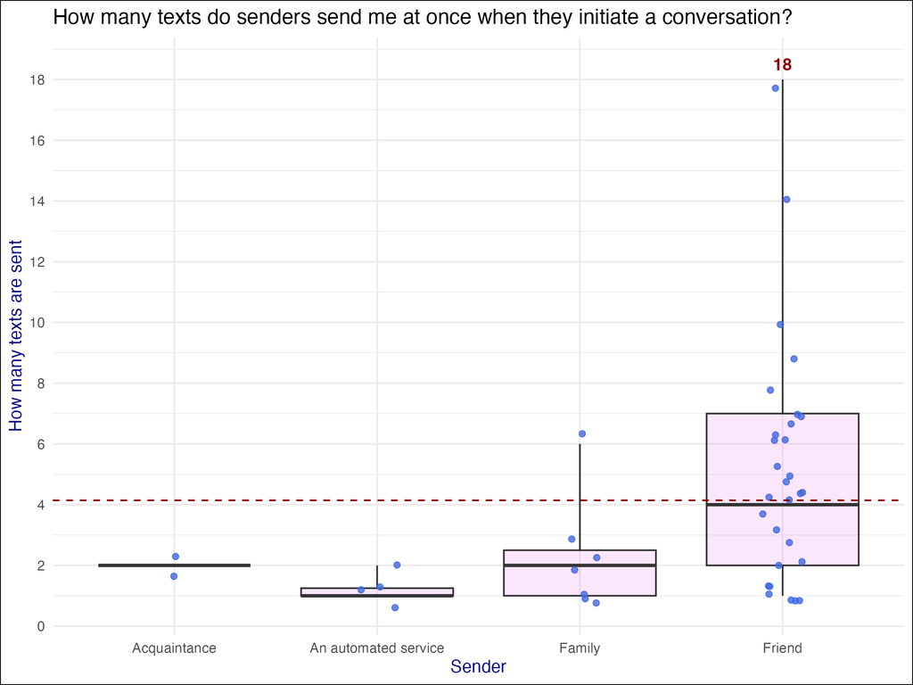

Each blue dot represents one sender and the number of texts they sent me at once when they initiated the conversation with me. The red dotted line represents the overall mean number of texts someone sends at once. The maximum number of texts I have recieved at once from someone is 18 texts from a friend. The range for acquaintances, automated services, and family is small and is almost always 3 texts or less. The range for friends is much larger because of 2 instances where they sent more than 10 texts at once. 50% of texts from friends range from 2-7 texts sent at once when they initiate a conversation.